# OA vs. Price Statistical Model

## Did prior move

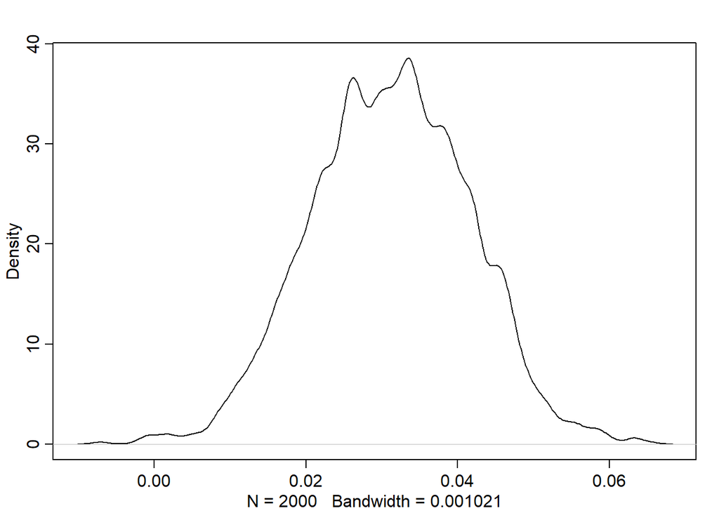

```r
dens(post$b_OA)
```

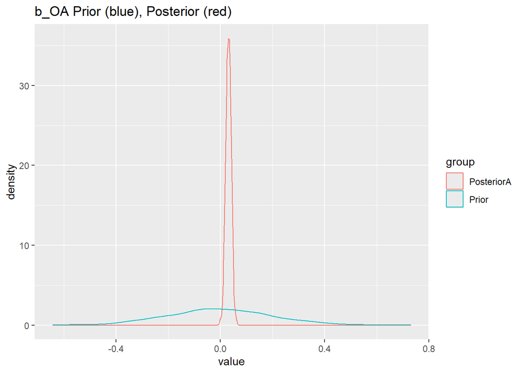

```r
prior_moved_df <- data.frame(
  #value = c(rnorm(2000, 0, 0.2), post$b_OA[,1], post$b_OA[,2]),
  value = c(rnorm(2000, 0, 0.2), post$b_OA),
  group = rep(c("Prior","PosteriorA"), each = 2000)
)

ggplot(prior_moved_df, aes(x = value)) +
  geom_density(aes(colour = group)) +
  labs(title = "b_OA Prior (blue), Posterior (red)")
```

## Discipline offsets

Get back to scale of actual dollar amounts

```r
# convert entire alpha matrix at once on NOT data.frame version, sometimes you want to keep the named list version
baseline_dollars <- as.data.frame(exp(post$a))

colnames(baseline_dollars) <- c('P1D1', 'P1D2', 'P1D3', 'P1D4')    #THIS CHANGED WHEN ALPHA IS A MATRIX
precis(as.data.frame(baseline_dollars))
```

```
         mean        sd      5.5%    94.5%  histogram
P1D1 1635.559  260.4073 1254.5656 2093.351 ▁▃▇▇▃▁▁▁▁▁
P1D2 3793.590 1031.6702 2439.9241 5674.979  ▁▃▇▃▂▁▁▁▁
P1D3 2984.476  495.1300 2243.0911 3822.349   ▁▃▇▇▂▁▁▁
P1D4 1643.467  541.7934  968.2128 2586.023  ▁▇▇▂▁▁▁▁▁
```

```r
#dens(baseline_dollars$P1D4 - baseline_dollars$P1D1)
```

```r
post_data_frame <- post_data_frame |>
  mutate(across(
    starts_with("a."), ~ exp(.x),
    .names = "exp_{.col}")   # to keep original values, include name for new columns
    )

post_data_frame |>
  select(last_col(9):last_col()) |>   # only last 10 columns
  head()
```

```
    mu.300   mu.301   mu.302   mu.303   mu.304   mu.305  exp_a.1  exp_a.2
1 9.573083 9.565413 7.908321 7.889957 7.926040 7.906078 1610.352 3397.750
2 9.586848 9.587236 7.996365 7.975351 8.015608 7.993488 1592.629 3016.782
3 9.629551 9.624741 7.916449 7.896620 7.935189 7.913909 1531.060 2954.501
4 9.747773 9.739880 7.965492 7.944452 7.985692 7.962892 1486.216 3237.534
5 9.634939 9.623779 7.878399 7.859938 7.896599 7.876261 1560.447 4790.444
6 9.707509 9.691605 7.953372 7.935780 7.971310 7.951514 1573.152 4742.893
   exp_a.3  exp_a.4
1 2887.238 1359.445
2 2947.255 1229.940
3 2920.295 1107.064
4 2907.829 1169.664
5 2803.321 1127.337
6 2857.356 1085.026
```

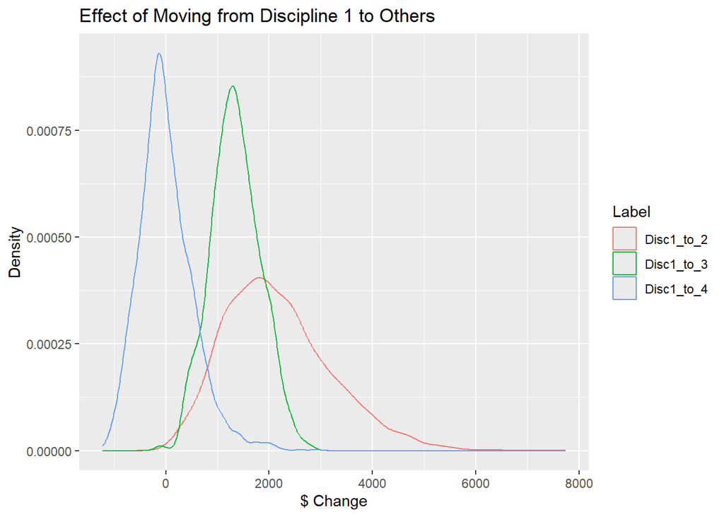

```r
post_data_frame <- post_data_frame |>
  mutate(Disc1_to_2 = exp_a.2 - exp_a.1,
         Disc1_to_3 = exp_a.3 - exp_a.1,
         Disc1_to_4 = exp_a.4 - exp_a.1)

post_data_frame |>
  select(Disc1_to_2, Disc1_to_3, Disc1_to_4) |>
  pivot_longer(cols = c(Disc1_to_2, Disc1_to_3, Disc1_to_4),
             names_to = 'Label',
             values_to = 'Value') |>

  ggplot(aes(x=Value)) +
    geom_density(aes(colour = Label)) +

    labs(title = "Effect of Moving from Discipline 1 to Others", x = "$ Change", y = "Density")
```

```r
post_data_frame |>
  select(Disc1_to_2, Disc1_to_3, Disc1_to_4) |>
  summarise(mean(Disc1_to_2),
            mean(Disc1_to_3),
            mean(Disc1_to_4))
```

```
  mean(Disc1_to_2) mean(Disc1_to_3) mean(Disc1_to_4)
1         2158.032         1348.917          7.90864
```

## Percentage Impact per 1 SD Shift, (exp(beta) - 1) * 100

log(DV) = Intercept + B1 * IV “One unit increase in IV is associated with a (B1 * 100) percent increase in DV.”

Interpret the exponentiated coefficients as multiplicative effects on price. For example: if beta_oa = -0.2, then a 1-SD increase in OA_percent multiplies price by exp(-0.2) ≈ 0.82 → ~18% decrease.

If you log transform an outcome and model it in a linear regression using the following formula specification: log(y) ~ x, the coefficient β1 is a mean difference of the log outcome comparing adjacent units of X. This is practically useless, so we exponentiate the parameter e^β1 and interpret this value as a geometric mean difference.

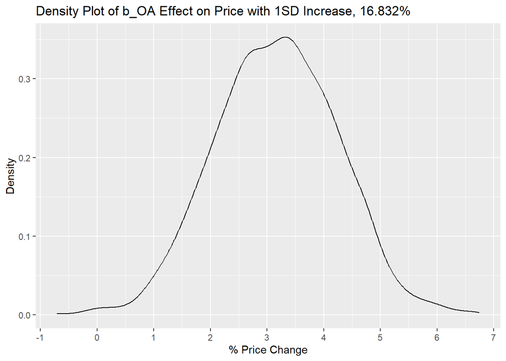

```r
post_data_frame <- post_data_frame |>
  mutate(
    OA_pct_change   = (exp(b_OA) - 1) * 100,
    #OA.2_pct_change   = (exp(b_OA.2) - 1) * 100,
    Volume_pct_change = (exp(b_articles) - 1) * 100,
    IF_pct_change   = (exp(b_IF) - 1) * 100,
    WoS_pct_change   = (exp(b_WoS) - 1) * 100
)

#precis(post_data_frame, pars = c('OA_pct_change', 'Volume_pct_change', 'IF_pct_change'))
#precis_plot(precis(post_data_frame))

post_data_frame |>
  #select(OA_pct_change) |>
  # pivot_longer(cols = OA_pct_change),
  #            names_to = 'Label',
  #            values_to = 'Pct') |>

  ggplot(aes(x=OA_pct_change)) +
    geom_density() +
    scale_x_continuous(breaks = seq(-1, 7, by = 1)) +
    labs(title = glue("Density Plot of b_OA Effect on Price with 1SD Increase, {round(sd(dat$OA_raw), 3)}%"), x = "% Price Change", y = "Density")
```

```r
post_data_frame |>
  filter(b_OA < 0)
```

[output not shown]

[output cut: 412 more lines]

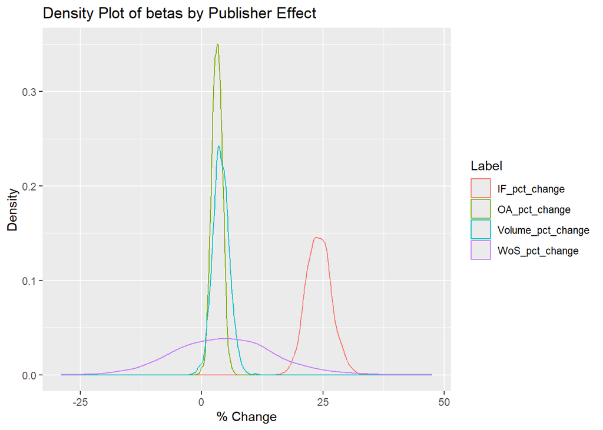

```r
post_data_frame |>
  select(Volume_pct_change, IF_pct_change, WoS_pct_change, OA_pct_change) |>
  pivot_longer(cols = c(Volume_pct_change, IF_pct_change, WoS_pct_change, OA_pct_change),
             names_to = 'Label',
             values_to = 'Pct') |>

  ggplot(aes(x=Pct)) +
    geom_density(aes(colour = Label)) +
    labs(title = "Density Plot of betas by Publisher Effect", x = "% Change", y = "Density")
```

```r
post_data_frame |>
  select(Volume_pct_change, IF_pct_change, WoS_pct_change, OA_pct_change) |>
  summarise(mean(Volume_pct_change),
            mean(IF_pct_change),
            mean(WoS_pct_change),
            mean(OA_pct_change))
```

```
  mean(Volume_pct_change) mean(IF_pct_change) mean(WoS_pct_change)
1                3.982437             24.1528             4.763742
  mean(OA_pct_change)
1             3.16945
```

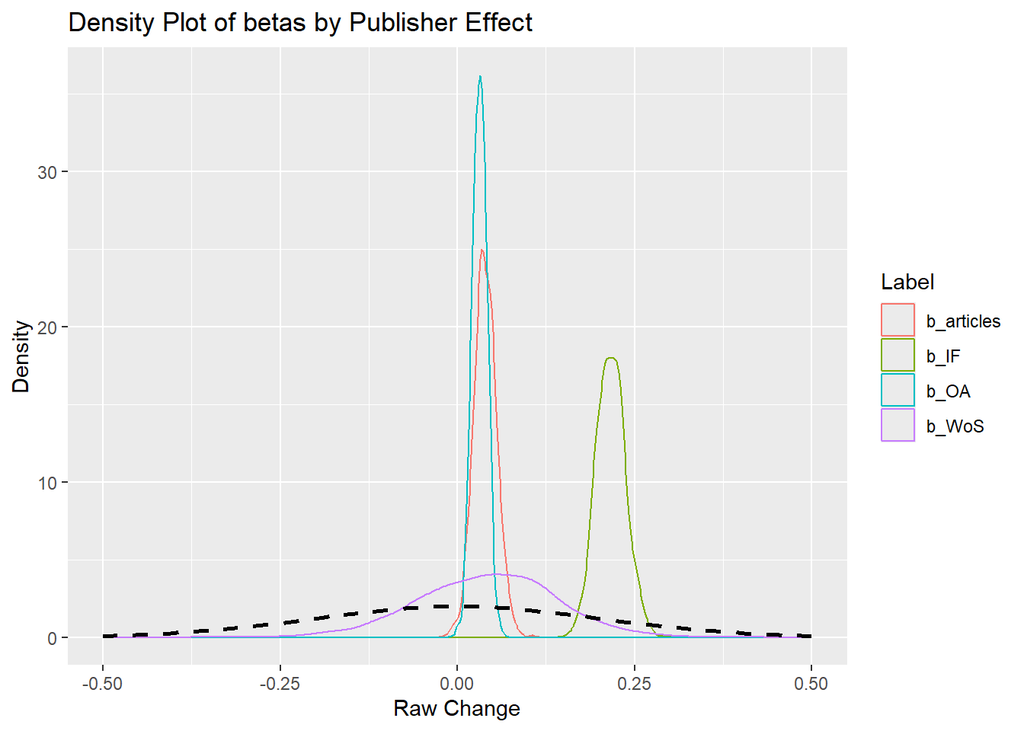

```r
post_data_frame |>
  select(b_articles, b_IF, b_WoS, b_OA) |>
  pivot_longer(cols = c(b_articles, b_IF, b_WoS, b_OA),
             names_to = 'Label',
             values_to = 'Pct') |>

  ggplot(aes(x=Pct )) +
    geom_density(aes(colour = Label) ) +
    labs(title = "Density Plot of betas by Publisher Effect", x = "Raw Change", y = "Density") +
    xlim(c(-0.5, 0.5) ) +

  stat_function(fun = dnorm,
                args = list(mean = 0,
                            sd = 0.2),
                color = "black",
                linewidth = 1,
                linetype = "dashed")
```

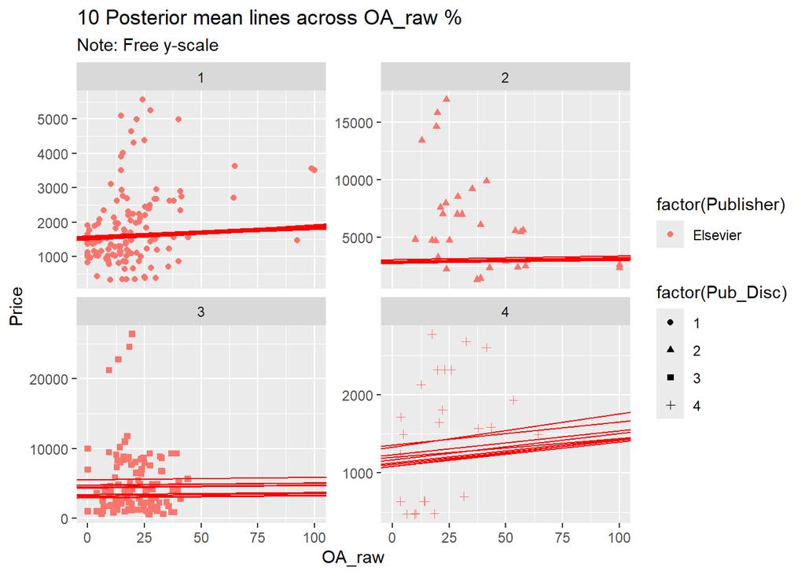

```r
# plot the data

post_data_frame_10 <- post_data_frame |> slice_head(n = 10)

line_data <- tibble(
  Pub_Disc = rep( c(1, 2, 3, 4), each = 10 ),  # 1,1,1,1,2,2,2,2, etc

  b_int = c(post_data_frame_10$exp_a.1,   # 10 rows of a_1 for Pub_Disc = 1
            post_data_frame_10$exp_a.3,
            post_data_frame_10$exp_a.2,
            post_data_frame_10$exp_a.4
            ),

  slope = rep( (exp(post_data_frame_10$b_OA) - 1) * 100, 4)  # repeat 10 rows 4 times
)


dat |>
  ggplot(aes(x = OA_raw,
             y = Price,
             shape = factor(Pub_Disc) )
         ) +
   geom_point( aes( colour = factor(Publisher) ) ) +

   geom_abline(data = line_data, aes(intercept = b_int, slope = slope), color = "red") +

   labs(title = "10 Posterior mean lines across OA_raw %",
        subtitle = "Note: Free y-scale") +
   facet_wrap(~Pub_Disc, scales = "free_y")
```

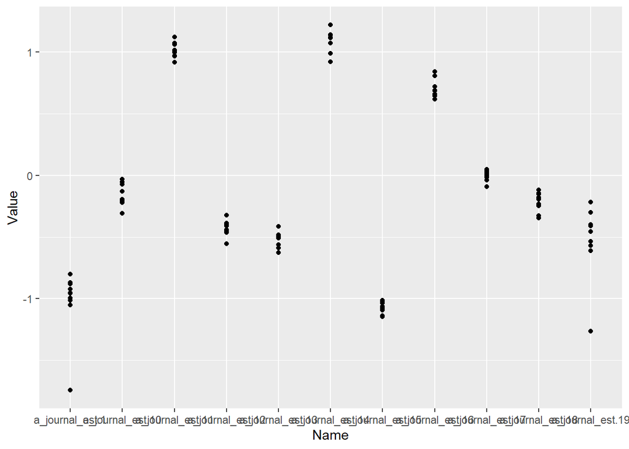

```r
post_data_frame_10 |>
  select(starts_with('a_journal_est.1') ) |>
  pivot_longer(cols = !c(),
               names_to = 'Name',
               values_to = 'Value') |>
  ggplot() +
  geom_point(aes(x = Name, y = Value) )
```

```r
summary <- dat |>
  group_by(Pub, Disc, Year) |>
  summarise(mean_OA_raw = mean(OA_raw))
```

```
`summarise()` has regrouped the output.
ℹ Summaries were computed grouped by Pub, Disc, and Year.
ℹ Output is grouped by Pub and Disc.
ℹ Use `summarise(.groups = "drop_last")` to silence this message.
ℹ Use `summarise(.by = c(Pub, Disc, Year))` for per-operation grouping
  (`?dplyr::dplyr_by`) instead.
```

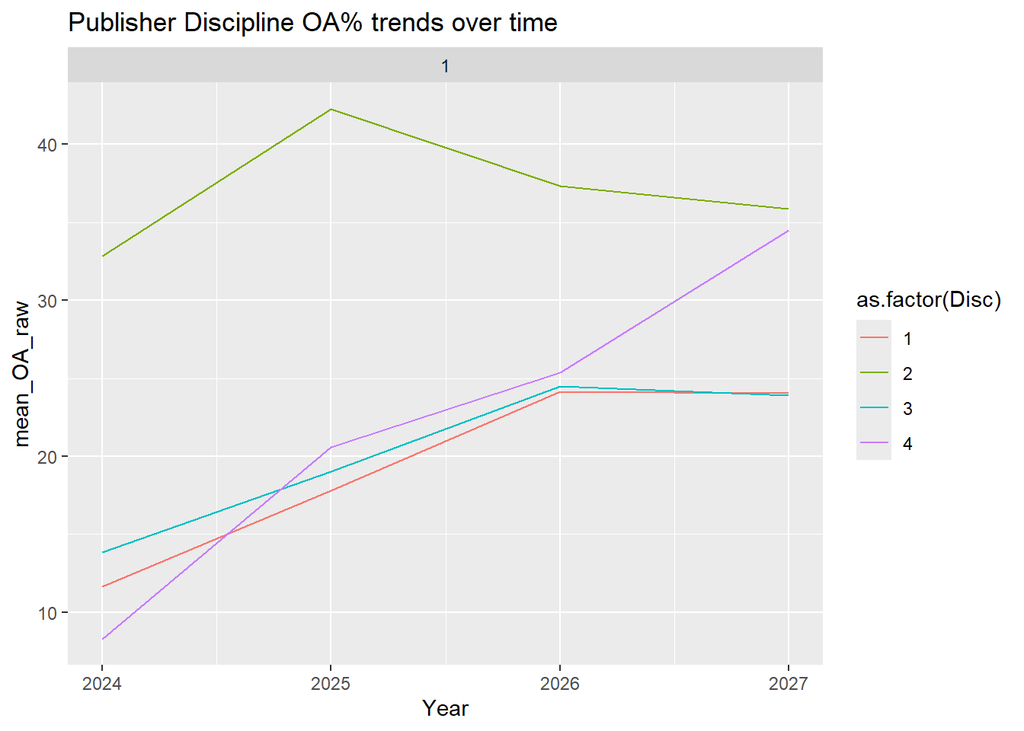

```r
summary |>
  ggplot(aes(x = Year, y = mean_OA_raw, colour = as.factor(Disc), group = as.factor(Disc))) +
  geom_line() +
  #geom_smooth(method = "lm") +
  facet_wrap(~Pub) +
  labs(title = 'Publisher Discipline OA% trends over time')
```

# Compare st devs

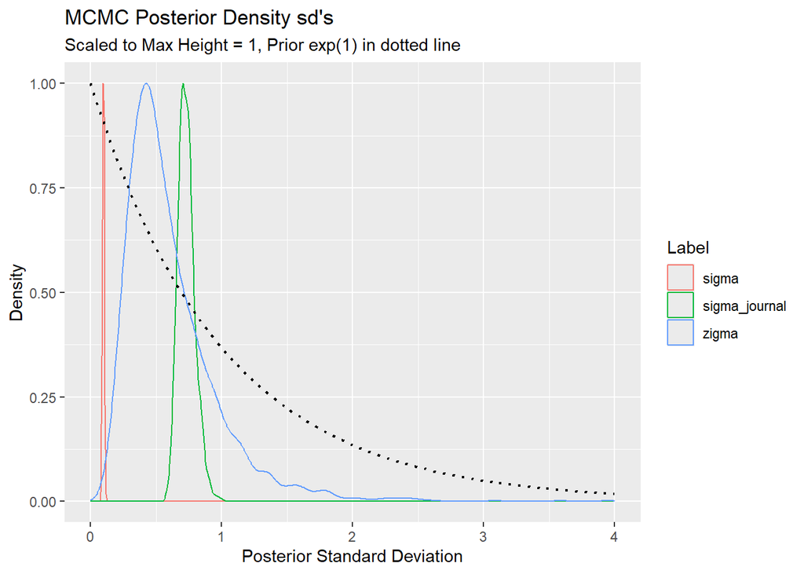

```r
# st devs and did the prior move?

post_data_frame |>
  select(sigma, sigma_journal, zigma) |>
  pivot_longer(cols = c(sigma, sigma_journal, zigma),
             names_to = 'Label',
             values_to = 'Value') |>


  ggplot(aes(x=Value) ) +
  geom_density(aes(y = after_stat(scaled),
                   colour = Label) )+

  geom_function(fun = dexp,
                args = list(rate = 1),
                linetype = "dotted",
                linewidth = 0.8
                ) +

  labs(title = "MCMC Posterior Density sd's",
         subtitle = "Scaled to Max Height = 1, Prior exp(1) in dotted line",
         x = "Posterior Standard Deviation",
         y = "Density") +

  xlim(c(0,4))
```